# TripleClasses

```python
from fastai import *
from fastai.text import *
```

```python
#import torch
#defaults.device = torch.device('cpu')

# this is to resolve issue of 'RuntimeError: DataLoader worker is killed by signal' when running learn_clas.lr_find()
```

## Load the data, prepare the language model

What is a language model? It has a very specific meaning. A language model is something which predicts next word in a sentence. To predict next word in a sentence you need to know quite a lot about the English language.

https://forums.fast.ai/t/deep-learning-lesson-4-notes/30983

Why is that useful? Because at that point we have got a model that knows how to complete sentences like this. So it knows quite a lot about English and a lot about how the world works. What kinds of things tend to be hot in different situations, for instance. Ideally, it would learn things like in 1996 in a speech to the United Nations, United States President **__** said… That will be a really good language model because it needs to know who was the president in that year. Getting really good at training language model is a great way to learn or teach a neural net a lot about what is our world, what’s in our world or how do things work in our world. It’s really a fascinating topic.

```python
dataset = pd.read_csv('trial.csv', sep = ',')
```

```python
df = dataset[['overall', 'reviewText']]
```

```python
df.head()
```

|  | overall | reviewText |
| --- | --- | --- |
| 0 | 1 | This is NOT what you get. This case has a stic... |
| 1 | 1 | Headline says 30000 mah\nDiscription reads 800... |
| 2 | 1 | Fit the phone nicely, but the first time I dro... |
| 3 | 1 | I ordered 2 of these. I bent the clip on mine... |
| 4 | 1 | Cheap material |

```python
df = df.replace({'overall': {1: 'Neg', 2: 'Neg', 3: 'Neu', 4: 'Pos', 5: 'Pos'}})
```

```python
len(df)
```

```
13190
```

```python
df['overall'].unique()
```

```
array(['Neg', 'Neu', 'Pos'], dtype=object)
```

Take unlabelled dataset, use it to fine-tune the pretrained model built with wikitext-103 dataset

```python
df.to_csv('tripleclasses.csv', sep=',')
```

```python
path = ''
bs=48
data_lm = (TextList.from_df(df, cols ='reviewText')
          .split_by_rand_pct(0.2)
          .label_for_lm()
          .databunch(bs=bs))
```

```python
data_lm.save('data_lm_export_tri.pkl')
```

```python
data_lm =load_data('', 'data_lm_export_tri.pkl')
```

```python
data_lm.show_batch()
```

| idx | text |
| --- | --- |
| 0 | clip was n't strong enough to hold . xxmaj neither case would hold a xxmaj samsung xxup s3 with a cover on it , and i 'm talking only a xxunk cover , not one of the bulletproof xxmaj xxunk - xxmaj spe… |
| 1 | . xxmaj adjusted the case a few times but still goes off on its own . xxmaj makes xxunk annoying as you end up hitting the back button . xxmaj maybe i will cut out the button so it does n't touch . xx… |
| 2 | i love this item however i dropped my galaxy 3 in an outer belt case with this case on it and the case cracked after three weeks of usage . xxmaj its a pretty case however it does little in terms of p… |
| 3 | they do not adhesive very well , and along with the xxmaj xxunk car mount , is complete garbage . wish i had done my home work before buying . xxmaj if you have a phone that has a xxunk this the magne… |
| 4 | . xxmaj do n't bother buying this . xxbos xxmaj nice product perfect fit ... only problem xxunk xxunk to replace them .. but you ca n't reach them . xxmaj sent email no response xxbos xxmaj dead on ar… |

Run the above code once, load the data_lm whenever needed

We can then put this in a learner object very easily with a model loaded with the pretrained weights. They'll be downloaded the first time you'll execute the following line and stored in ~/.fastai/models (or a specified path)

```python
learn = language_model_learner(data_lm, arch=AWD_LSTM, pretrained=True, drop_mult=0.3)
```

```python
learn.lr_find()
```

0.00% [0/1 00:00<00:00]

| epoch | train_loss | valid_loss | accuracy | time |
| --- | --- | --- | --- | --- |

93.40% [99/106 13:12<00:56 9.7787]

```
LR Finder is complete, type {learner_name}.recorder.plot() to see the graph.
```

```
Min numerical gradient: 2.29E-02
Min loss divided by 10: 3.63E-02
```

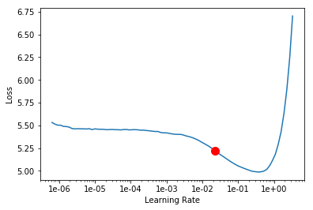

```python
learn.recorder.plot(suggestion = True)
```

```python
# max_lr will be the 10th of the mininum of the curve = min lss divided by 10: 3.63E-02
learn.fit_one_cycle(1, 3.63e-2, moms=(0.8, 0.7))
```

| epoch | train_loss | valid_loss | accuracy | time |
| --- | --- | --- | --- | --- |
| 0 | 3.886177 | 3.612242 | 0.281581 | 15:26 |

```python
learn.save('fit_head_tri')
```

```python
learn.load('fit_head_tri')
```

[output not shown]

[output cut: 23 more lines]

[output not shown]

To complete the fine-tuning, we can then unfreeze and launch a new training

```python
learn.unfreeze()
```

About learning rate - https://towardsdatascience.com/finding-good-learning-rate-and-the-one-cycle-policy-7159fe1db5d6

```python
learn.fit_one_cycle(10, 3.63e-3, moms=(0.8, 0.7))
# max_lr is 10th of the max_lr of the first time
```

| epoch | train_loss | valid_loss | accuracy | time |
| --- | --- | --- | --- | --- |
| 0 | 3.395394 | 3.492257 | 0.296892 | 30:50 |
| 1 | 3.302769 | 3.459392 | 0.299096 | 30:42 |
| 2 | 3.135914 | 3.482728 | 0.298402 | 30:44 |
| 3 | 2.838639 | 3.550898 | 0.294588 | 30:46 |
| 4 | 2.430240 | 3.694879 | 0.287709 | 30:46 |
| 5 | 1.953296 | 3.904052 | 0.276334 | 30:44 |
| 6 | 1.498178 | 4.123082 | 0.272972 | 30:43 |
| 7 | 1.146702 | 4.286882 | 0.269169 | 30:41 |
| 8 | 0.924764 | 4.371945 | 0.266942 | 30:40 |
| 9 | 0.842619 | 4.402838 | 0.267130 | 30:40 |

```python
learn.save('fine_tuned_tri')
```

```python
learn.load('fine_tuned_tri')
```

[output not shown]

[output cut: 23 more lines]

[output not shown]

How good is our model? Well, let's try to see what is predicts after a few given words

How to judge the wellness of the lm(language mode) at this step is to be figured out

```python
TEXT = 'I like the phone case as'
N_WORDS = 20
N_SENTENCES = 3
```

```python
print("\n".join(learn.predict(TEXT, N_WORDS, temperature=0.75) for _ in range(N_SENTENCES)))
```

```
I like the phone case as i usually have the phone already and it works just fine . The only reason i did n't give
I like the phone case as it is very bulky , but it is like about a large phone . Keeps the phone thin and
I like the phone case as i have no other problems it did n't know it does not have a problem with the screen now .
```

```python
TEXT2 = 'bad quality'
N_WORDS2 = 40
N_SENTENCES2 = 2
```

```python
print("\n".join(learn.predict(TEXT2, N_WORDS2, temperature=0.10) for _ in range(N_SENTENCES2)))
```

```
bad quality xxbos This is a great case ! i 've had it for over a year and still love it ! Very durable and i love the color . xxbos This is a great case ! i 've
bad quality xxbos This is a great case ! i 've had it for over a year and still love it ! Very sleek , sturdy and just as described . xxbos This is a great case ! i
```

We have to save the model but also it's encoder, the part that's responsible for creating and updating the hidden state. For the next part, we don't care about the part that tries to guess the next word.

```python
learn.save_encoder('fine_tuned_enc_tri')
```

## Classifier

Now we'll create a new data object that only grabs the labelled data and keeps those labels. Again, this line takes a bit of time

```python
#defaults.cpus=1
path = ''
data_clas = (TextList.from_csv(path, 'tripleclasses.csv', cols = 'reviewText', vocab=data_lm.vocab)
             .split_by_rand_pct(0.3)
             .label_from_df(cols='overall')
             #.databunch(bs=bs, num_workers=0,))
             .databunch(bs=bs))
```

defaults.cpus = 1, to avoid issue: BrokenProcessPool: A process in the process pool was terminated abruptly while the future was running or pending.

num_workers = 0, to avoid issue: RuntimeError: DataLoader worker is killed by signal

```python
data_clas.save('multi_data_clas_export_tri.pkl')
```

```python
data_clas = load_data('', 'multi_data_clas_export_tri.pkl')
```

```python
data_clas.show_batch()
```

| text | target |
| --- | --- |
| xxbos xxup this xxup phone xxup has xxup to xxup be xxup charged xxup every xxup half xxup an xxup hour . xxup for a 3 g xxup phone xxup this xxup is a xxup terrible xxup terrible xxup product xxup an… | Neg |
| xxbos xxup pros : \n - xxmaj super durable . xxmaj very good quality materials throughout . \n - xxmaj it locks with two strong xxunk which can then be secure with small xxunk via the 2 holes set near… | Pos |
| xxbos i xxup only xxup rated a 4 xxup star xxup at xxup the xxup moment xxup because i xxup xxunk xxup used xxup them xxup yet xxup and xxup not xxup sure xxup when i xxup will , xxup at xxup the xxup… | Pos |
| xxbos xxmaj good purchase . xxmaj xxunk 14 , 16 . xxmaj update ; really happy with it . xxmaj use daily , charge during the day using my xxmaj anker solar panel . xxmaj charges my phones , xxunk then … | Pos |
| xxbos xxmaj this is xxmaj great xxmaj product ! ! xxmaj bought 2 pack , great to have an extra protector . xxmaj but never thought needed it . xxmaj dropped phone the other day from counter , landed o… | Pos |

```python
learn_clas = text_classifier_learner(data_clas, arch = AWD_LSTM, drop_mult=0.3) # pretrained = True calls for arch=AWD-LSTM

#drop_mult by default 1: 1 will call underfitting. It's related to regularization,
# regularization might cause underfitting.
```

```python
learn_clas.load_encoder('fine_tuned_enc_tri')
learn_clas.freeze()
```

```python
learn_clas.lr_find()
```

0.00% [0/1 00:00<00:00]

| epoch | train_loss | valid_loss | accuracy | time |
| --- | --- | --- | --- | --- |

47.92% [92/192 03:31<03:50 2.8261]

```
LR Finder is complete, type {learner_name}.recorder.plot() to see the graph.
```

https://github.com/fastai/fastai/issues/1492

```
Min numerical gradient: 3.98E-02
Min loss divided by 10: 5.25E-02
```

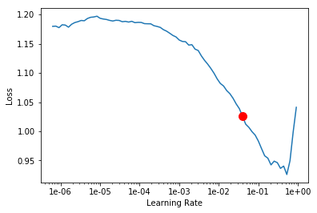

```python
learn_clas.recorder.plot(suggestion = True, figsize = (9,9))
```

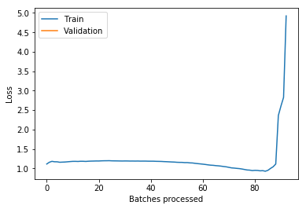

```python
learn_clas.recorder.plot_losses()
```

```python
learn_clas.fit_one_cycle(1, 5.25e-2, moms=(0.8,0.7))
```

| epoch | train_loss | valid_loss | accuracy | time |
| --- | --- | --- | --- | --- |
| 0 | 0.606321 | 0.563615 | 0.773313 | 10:24 |

```python
learn_clas.save('first_tri')
```

```python
learn_clas.load('first_tri')
```

[output not shown]

[output cut: 37 more lines]

[output not shown]

```python
learn_clas.freeze_to(-2)
learn_clas.fit_one_cycle(1, slice(5.25e-2/(2.6**4),5.25e-2), moms=(0.8,0.7))
```

| epoch | train_loss | valid_loss | accuracy | time |
| --- | --- | --- | --- | --- |
| 0 | 0.541450 | 0.567421 | 0.794036 | 12:32 |

```python
learn_clas.save('second_tri')
```

```python
learn_clas.load('second_tri')
```

[output not shown]

[output cut: 37 more lines]

[output not shown]